# Risk Factor Analysis

## Outcome Variable

**Outcome Variable:** dead624

## Predictor Variables

**Intervention Variable:** ever_sunderweight06

**Adjustment Set:**

- sex
- arm
- brthmon
- vagbrth
- impfloor
- hhwealth_quart
- W_mage
- W_mhtcm
- W_mwtkg
- W_mbmi
- W_meducyrs
- W_feducyrs
- W_nrooms
- W_parity
- impsan
- safeh20
- delta_vagbrth
- delta_impfloor
- delta_hhwealth_quart
- delta_W_mage
- delta_W_mhtcm
- delta_W_mwtkg
- delta_W_mbmi
- delta_W_meducyrs
- delta_W_feducyrs
- delta_W_nrooms
- delta_W_parity
- delta_impsan
- delta_safeh20

## Stratifying Variables

The analysis was stratified on these variable(s):

- studyid
- country

## Data Summary

| studyid | country | ever_sunderweight06 | dead624 | n_cell | n |
| --- | --- | --- | --- | --- | --- |
| Burkina Faso Zn | BURKINA FASO | 0 | 0 | 313 | 336 |
| Burkina Faso Zn | BURKINA FASO | 0 | 1 | 2 | 336 |
| Burkina Faso Zn | BURKINA FASO | 1 | 0 | 21 | 336 |
| Burkina Faso Zn | BURKINA FASO | 1 | 1 | 0 | 336 |
| EE | PAKISTAN | 0 | 0 | 215 | 375 |
| EE | PAKISTAN | 0 | 1 | 1 | 375 |
| EE | PAKISTAN | 1 | 0 | 156 | 375 |
| EE | PAKISTAN | 1 | 1 | 3 | 375 |
| GMS-Nepal | NEPAL | 0 | 0 | 508 | 592 |
| GMS-Nepal | NEPAL | 0 | 1 | 1 | 592 |
| GMS-Nepal | NEPAL | 1 | 0 | 82 | 592 |
| GMS-Nepal | NEPAL | 1 | 1 | 1 | 592 |
| iLiNS-DOSE | MALAWI | 0 | 0 | 1593 | 1759 |
| iLiNS-DOSE | MALAWI | 0 | 1 | 105 | 1759 |
| iLiNS-DOSE | MALAWI | 1 | 0 | 53 | 1759 |
| iLiNS-DOSE | MALAWI | 1 | 1 | 8 | 1759 |
| iLiNS-DYAD-M | MALAWI | 0 | 0 | 1057 | 1158 |
| iLiNS-DYAD-M | MALAWI | 0 | 1 | 19 | 1158 |
| iLiNS-DYAD-M | MALAWI | 1 | 0 | 77 | 1158 |
| iLiNS-DYAD-M | MALAWI | 1 | 1 | 5 | 1158 |
| JiVitA-3 | BANGLADESH | 0 | 0 | 17600 | 21023 |
| JiVitA-3 | BANGLADESH | 0 | 1 | 169 | 21023 |
| JiVitA-3 | BANGLADESH | 1 | 0 | 3153 | 21023 |
| JiVitA-3 | BANGLADESH | 1 | 1 | 101 | 21023 |
| JiVitA-4 | BANGLADESH | 0 | 0 | 4708 | 5266 |
| JiVitA-4 | BANGLADESH | 0 | 1 | 31 | 5266 |
| JiVitA-4 | BANGLADESH | 1 | 0 | 511 | 5266 |
| JiVitA-4 | BANGLADESH | 1 | 1 | 16 | 5266 |
| Keneba | GAMBIA | 0 | 0 | 2270 | 2464 |
| Keneba | GAMBIA | 0 | 1 | 30 | 2464 |
| Keneba | GAMBIA | 1 | 0 | 153 | 2464 |
| Keneba | GAMBIA | 1 | 1 | 11 | 2464 |
| MAL-ED | BANGLADESH | 0 | 0 | 224 | 240 |
| MAL-ED | BANGLADESH | 0 | 1 | 0 | 240 |
| MAL-ED | BANGLADESH | 1 | 0 | 16 | 240 |
| MAL-ED | BANGLADESH | 1 | 1 | 0 | 240 |
| MAL-ED | INDIA | 0 | 0 | 204 | 235 |
| MAL-ED | INDIA | 0 | 1 | 0 | 235 |
| MAL-ED | INDIA | 1 | 0 | 31 | 235 |
| MAL-ED | INDIA | 1 | 1 | 0 | 235 |
| MAL-ED | PERU | 0 | 0 | 263 | 273 |
| MAL-ED | PERU | 0 | 1 | 1 | 273 |
| MAL-ED | PERU | 1 | 0 | 9 | 273 |
| MAL-ED | PERU | 1 | 1 | 0 | 273 |
| MAL-ED | SOUTH AFRICA | 0 | 0 | 249 | 261 |
| MAL-ED | SOUTH AFRICA | 0 | 1 | 0 | 261 |
| MAL-ED | SOUTH AFRICA | 1 | 0 | 12 | 261 |
| MAL-ED | SOUTH AFRICA | 1 | 1 | 0 | 261 |
| MAL-ED | TANZANIA, UNITED REPUBLIC OF | 0 | 0 | 237 | 245 |
| MAL-ED | TANZANIA, UNITED REPUBLIC OF | 0 | 1 | 0 | 245 |
| MAL-ED | TANZANIA, UNITED REPUBLIC OF | 1 | 0 | 8 | 245 |
| MAL-ED | TANZANIA, UNITED REPUBLIC OF | 1 | 1 | 0 | 245 |
| PROVIDE | BANGLADESH | 0 | 0 | 572 | 617 |
| PROVIDE | BANGLADESH | 0 | 1 | 2 | 617 |
| PROVIDE | BANGLADESH | 1 | 0 | 43 | 617 |
| PROVIDE | BANGLADESH | 1 | 1 | 0 | 617 |
| SAS-CompFeed | INDIA | 0 | 0 | 1164 | 1389 |
| SAS-CompFeed | INDIA | 0 | 1 | 5 | 1389 |
| SAS-CompFeed | INDIA | 1 | 0 | 213 | 1389 |
| SAS-CompFeed | INDIA | 1 | 1 | 7 | 1389 |
| SAS-FoodSuppl | INDIA | 0 | 0 | 291 | 400 |
| SAS-FoodSuppl | INDIA | 0 | 1 | 1 | 400 |
| SAS-FoodSuppl | INDIA | 1 | 0 | 105 | 400 |
| SAS-FoodSuppl | INDIA | 1 | 1 | 3 | 400 |
| TanzaniaChild2 | TANZANIA, UNITED REPUBLIC OF | 0 | 0 | 2034 | 2096 |
| TanzaniaChild2 | TANZANIA, UNITED REPUBLIC OF | 0 | 1 | 0 | 2096 |
| TanzaniaChild2 | TANZANIA, UNITED REPUBLIC OF | 1 | 0 | 62 | 2096 |
| TanzaniaChild2 | TANZANIA, UNITED REPUBLIC OF | 1 | 1 | 0 | 2096 |
| VITAMIN-A | INDIA | 0 | 0 | 2673 | 3615 |
| VITAMIN-A | INDIA | 0 | 1 | 14 | 3615 |
| VITAMIN-A | INDIA | 1 | 0 | 910 | 3615 |
| VITAMIN-A | INDIA | 1 | 1 | 18 | 3615 |
| ZVITAMBO | ZIMBABWE | 0 | 0 | 10798 | 11707 |
| ZVITAMBO | ZIMBABWE | 0 | 1 | 296 | 11707 |
| ZVITAMBO | ZIMBABWE | 1 | 0 | 503 | 11707 |
| ZVITAMBO | ZIMBABWE | 1 | 1 | 110 | 11707 |

The following strata were considered:

- studyid: Burkina Faso Zn, country: BURKINA FASO
- studyid: EE, country: PAKISTAN
- studyid: GMS-Nepal, country: NEPAL
- studyid: iLiNS-DOSE, country: MALAWI
- studyid: iLiNS-DYAD-M, country: MALAWI
- studyid: JiVitA-3, country: BANGLADESH
- studyid: JiVitA-4, country: BANGLADESH
- studyid: Keneba, country: GAMBIA
- studyid: MAL-ED, country: BANGLADESH
- studyid: MAL-ED, country: INDIA
- studyid: MAL-ED, country: PERU
- studyid: MAL-ED, country: SOUTH AFRICA
- studyid: MAL-ED, country: TANZANIA, UNITED REPUBLIC OF
- studyid: PROVIDE, country: BANGLADESH
- studyid: SAS-CompFeed, country: INDIA
- studyid: SAS-FoodSuppl, country: INDIA
- studyid: TanzaniaChild2, country: TANZANIA, UNITED REPUBLIC OF
- studyid: VITAMIN-A, country: INDIA
- studyid: ZVITAMBO, country: ZIMBABWE

### Dropped Strata

Some strata were dropped due to rare outcomes:

- studyid: Burkina Faso Zn, country: BURKINA FASO
- studyid: EE, country: PAKISTAN
- studyid: GMS-Nepal, country: NEPAL
- studyid: MAL-ED, country: BANGLADESH
- studyid: MAL-ED, country: INDIA
- studyid: MAL-ED, country: PERU
- studyid: MAL-ED, country: SOUTH AFRICA
- studyid: MAL-ED, country: TANZANIA, UNITED REPUBLIC OF
- studyid: PROVIDE, country: BANGLADESH
- studyid: SAS-FoodSuppl, country: INDIA
- studyid: TanzaniaChild2, country: TANZANIA, UNITED REPUBLIC OF

## Methods Detail

We’re interested in the causal parameters $E[Y_a]$ for all values of $a \in \mathcal{A}$. These parameters represent the mean outcome if, possibly contrary to fact, we intervened to set all units to have $A=a$. Under the randomization and positivity assumptions, these are identified by the statistical parameters $\psi_a=E_W[E_{Y|A,W}(Y|A=a,W)]$. In addition, we’re interested in the mean of $Y$, $E[Y]$ under no intervention (the observed mean). We will estimate these parameters by using SuperLearner to fit the relevant likelihood factors – $E_{Y|A,W}(Y|A=a,W)$ and $p(A=a|W)$, and then updating our likelihood fit using a joint TMLE.

For unadjusted analyses ($W=\{\}$), initial likelihoods were estimated using Lrnr_glm to estimate the simple $E(Y|A)$ and Lrnr_mean to estimate $p(A)$. For adjusted analyses, a small library containing Lrnr_glmnet, Lrnr_xgboost, and Lrnr_mean was used.

Having estimated these parameters, we will then use the delta method to estimate relative risks and attributable risks relative to a prespecified baseline level of $A$.

# Results Detail

## Results Plots

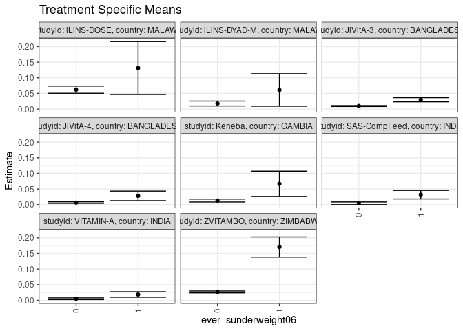

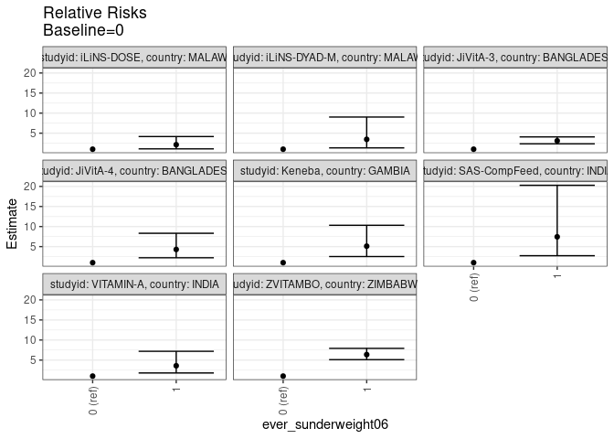

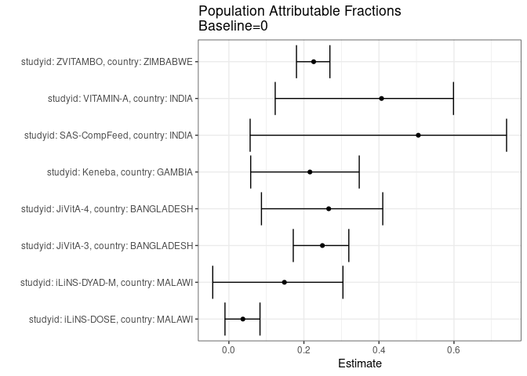

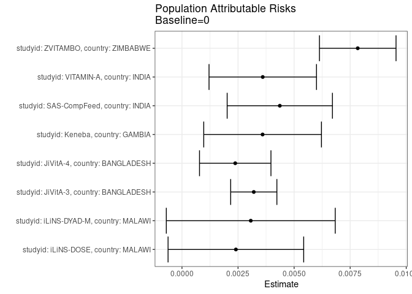

## Results Table

### Parameter: TSM

| studyid | country | intervention_level | baseline_level | estimate | ci_lower | ci_upper |
| --- | --- | --- | --- | --- | --- | --- |
| iLiNS-DOSE | MALAWI | 0 | NA | 0.0618375 | 0.0503779 | 0.0732970 |
| iLiNS-DOSE | MALAWI | 1 | NA | 0.1311475 | 0.0464131 | 0.2158819 |
| iLiNS-DYAD-M | MALAWI | 0 | NA | 0.0176580 | 0.0097851 | 0.0255308 |
| iLiNS-DYAD-M | MALAWI | 1 | NA | 0.0609756 | 0.0091618 | 0.1127894 |
| JiVitA-3 | BANGLADESH | 0 | NA | 0.0096415 | 0.0081514 | 0.0111315 |
| JiVitA-3 | BANGLADESH | 1 | NA | 0.0297382 | 0.0230644 | 0.0364119 |
| JiVitA-4 | BANGLADESH | 0 | NA | 0.0065503 | 0.0040861 | 0.0090145 |
| JiVitA-4 | BANGLADESH | 1 | NA | 0.0281255 | 0.0129135 | 0.0433376 |
| Keneba | GAMBIA | 0 | NA | 0.0130448 | 0.0084041 | 0.0176854 |
| Keneba | GAMBIA | 1 | NA | 0.0666245 | 0.0262243 | 0.1070247 |
| SAS-CompFeed | INDIA | 0 | NA | 0.0042772 | -0.0001115 | 0.0086658 |
| SAS-CompFeed | INDIA | 1 | NA | 0.0318182 | 0.0181644 | 0.0454719 |
| VITAMIN-A | INDIA | 0 | NA | 0.0052501 | 0.0025119 | 0.0079882 |
| VITAMIN-A | INDIA | 1 | NA | 0.0187897 | 0.0100835 | 0.0274959 |
| ZVITAMBO | ZIMBABWE | 0 | NA | 0.0268425 | 0.0238322 | 0.0298528 |
| ZVITAMBO | ZIMBABWE | 1 | NA | 0.1707246 | 0.1384986 | 0.2029506 |

### Parameter: E(Y)

| studyid | country | intervention_level | baseline_level | estimate | ci_lower | ci_upper |
| --- | --- | --- | --- | --- | --- | --- |
| iLiNS-DOSE | MALAWI | NA | NA | 0.0642410 | 0.0527799 | 0.0757022 |
| iLiNS-DYAD-M | MALAWI | NA | NA | 0.0207254 | 0.0125165 | 0.0289343 |
| JiVitA-3 | BANGLADESH | NA | NA | 0.0128431 | 0.0112928 | 0.0143934 |
| JiVitA-4 | BANGLADESH | NA | NA | 0.0089252 | 0.0062212 | 0.0116291 |
| Keneba | GAMBIA | NA | NA | 0.0166396 | 0.0115878 | 0.0216914 |
| SAS-CompFeed | INDIA | NA | NA | 0.0086393 | 0.0042356 | 0.0130430 |
| VITAMIN-A | INDIA | NA | NA | 0.0088520 | 0.0057982 | 0.0119058 |
| ZVITAMBO | ZIMBABWE | NA | NA | 0.0346801 | 0.0313656 | 0.0379946 |

### Parameter: RR

| studyid | country | intervention_level | baseline_level | estimate | ci_lower | ci_upper |
| --- | --- | --- | --- | --- | --- | --- |
| iLiNS-DOSE | MALAWI | 0 | 0 | 1.000000 | 1.000000 | 1.000000 |
| iLiNS-DOSE | MALAWI | 1 | 0 | 2.120843 | 1.082921 | 4.153557 |
| iLiNS-DYAD-M | MALAWI | 0 | 0 | 1.000000 | 1.000000 | 1.000000 |
| iLiNS-DYAD-M | MALAWI | 1 | 0 | 3.453145 | 1.322700 | 9.015052 |
| JiVitA-3 | BANGLADESH | 0 | 0 | 1.000000 | 1.000000 | 1.000000 |
| JiVitA-3 | BANGLADESH | 1 | 0 | 3.084393 | 2.343863 | 4.058890 |
| JiVitA-4 | BANGLADESH | 0 | 0 | 1.000000 | 1.000000 | 1.000000 |
| JiVitA-4 | BANGLADESH | 1 | 0 | 4.293791 | 2.215578 | 8.321368 |
| Keneba | GAMBIA | 0 | 0 | 1.000000 | 1.000000 | 1.000000 |
| Keneba | GAMBIA | 1 | 0 | 5.107379 | 2.528035 | 10.318414 |
| SAS-CompFeed | INDIA | 0 | 0 | 1.000000 | 1.000000 | 1.000000 |
| SAS-CompFeed | INDIA | 1 | 0 | 7.439091 | 2.727800 | 20.287438 |
| VITAMIN-A | INDIA | 0 | 0 | 1.000000 | 1.000000 | 1.000000 |
| VITAMIN-A | INDIA | 1 | 0 | 3.578947 | 1.781767 | 7.188853 |
| ZVITAMBO | ZIMBABWE | 0 | 0 | 1.000000 | 1.000000 | 1.000000 |
| ZVITAMBO | ZIMBABWE | 1 | 0 | 6.360243 | 5.106867 | 7.921235 |

### Parameter: PAR

| studyid | country | intervention_level | baseline_level | estimate | ci_lower | ci_upper |
| --- | --- | --- | --- | --- | --- | --- |
| iLiNS-DOSE | MALAWI | 0 | NA | 0.0024036 | -0.0006203 | 0.0054275 |
| iLiNS-DYAD-M | MALAWI | 0 | NA | 0.0030674 | -0.0006986 | 0.0068334 |
| JiVitA-3 | BANGLADESH | 0 | NA | 0.0032016 | 0.0021712 | 0.0042320 |
| JiVitA-4 | BANGLADESH | 0 | NA | 0.0023749 | 0.0007823 | 0.0039675 |
| Keneba | GAMBIA | 0 | NA | 0.0035949 | 0.0009706 | 0.0062191 |
| SAS-CompFeed | INDIA | 0 | NA | 0.0043621 | 0.0020152 | 0.0067091 |
| VITAMIN-A | INDIA | 0 | NA | 0.0036019 | 0.0012058 | 0.0059981 |
| ZVITAMBO | ZIMBABWE | 0 | NA | 0.0078376 | 0.0061301 | 0.0095452 |

### Parameter: PAF

| studyid | country | intervention_level | baseline_level | estimate | ci_lower | ci_upper |
| --- | --- | --- | --- | --- | --- | --- |
| iLiNS-DOSE | MALAWI | 0 | NA | 0.0374152 | -0.0103929 | 0.0829612 |
| iLiNS-DYAD-M | MALAWI | 0 | NA | 0.1480019 | -0.0430202 | 0.3040395 |
| JiVitA-3 | BANGLADESH | 0 | NA | 0.2492847 | 0.1716273 | 0.3196619 |
| JiVitA-4 | BANGLADESH | 0 | NA | 0.2660895 | 0.0868174 | 0.4101676 |
| Keneba | GAMBIA | 0 | NA | 0.2160419 | 0.0581499 | 0.3474648 |
| SAS-CompFeed | INDIA | 0 | NA | 0.5049187 | 0.0566503 | 0.7401754 |
| VITAMIN-A | INDIA | 0 | NA | 0.4069069 | 0.1234832 | 0.5986850 |
| ZVITAMBO | ZIMBABWE | 0 | NA | 0.2259984 | 0.1801815 | 0.2692547 |